# Исследование объявлений о продаже квартир

В вашем распоряжении данные сервиса Яндекс Недвижимость — архив объявлений о продаже квартир в Санкт-Петербурге и соседних населённых пунктах за несколько лет. Вам нужно научиться определять рыночную стоимость объектов недвижимости. Для этого проведите исследовательский анализ данных и установите параметры, влияющие на цену объектов. Это позволит построить автоматизированную систему: она отследит аномалии и мошенническую деятельность.

По каждой квартире на продажу доступны два вида данных. Первые вписаны пользователем, вторые — получены автоматически на основе картографических данных. Например, расстояние до центра, аэропорта и других объектов — эти данные автоматически получены из геосервисов. Количество парков и водоёмов также заполняется без участия пользователя.

# Откройте файл с данными и изучите общую информацию

```python
import pandas as pd
import matplotlib.pyplot as plt
import warnings
import numpy as np
```

```python
df = pd.read_csv('/datasets/real_estate_data.csv', sep = '\t')
df.info()
```

```
<class 'pandas.core.frame.DataFrame'>
RangeIndex: 23699 entries, 0 to 23698
Data columns (total 22 columns):
 #   Column                Non-Null Count  Dtype
---  ------                --------------  -----
 0   total_images          23699 non-null  int64
 1   last_price            23699 non-null  float64
 2   total_area            23699 non-null  float64
 3   first_day_exposition  23699 non-null  object
 4   rooms                 23699 non-null  int64
 5   ceiling_height        14504 non-null  float64
 6   floors_total          23613 non-null  float64
 7   living_area           21796 non-null  float64
 8   floor                 23699 non-null  int64
 9   is_apartment          2775 non-null   object
 10  studio                23699 non-null  bool
 11  open_plan             23699 non-null  bool
 12  kitchen_area          21421 non-null  float64
 13  balcony               12180 non-null  float64
 14  locality_name         23650 non-null  object
 15  airports_nearest      18157 non-null  float64
 16  cityCenters_nearest   18180 non-null  float64
 17  parks_around3000      18181 non-null  float64
 18  parks_nearest         8079 non-null   float64
 19  ponds_around3000      18181 non-null  float64
 20  ponds_nearest         9110 non-null   float64
 21  days_exposition       20518 non-null  float64
dtypes: bool(2), float64(14), int64(3), object(3)
memory usage: 3.7+ MB
```

- в таблице 22 столбца, типы данных: bool(2), float64(14), int64(3), object(3)

```
array([[<AxesSubplot:title={'center':'total_images'}>,
        <AxesSubplot:title={'center':'last_price'}>,
        <AxesSubplot:title={'center':'total_area'}>,
        <AxesSubplot:title={'center':'rooms'}>],
       [<AxesSubplot:title={'center':'ceiling_height'}>,
        <AxesSubplot:title={'center':'floors_total'}>,
        <AxesSubplot:title={'center':'living_area'}>,
        <AxesSubplot:title={'center':'floor'}>],
       [<AxesSubplot:title={'center':'kitchen_area'}>,
        <AxesSubplot:title={'center':'balcony'}>,
        <AxesSubplot:title={'center':'airports_nearest'}>,
        <AxesSubplot:title={'center':'cityCenters_nearest'}>],
       [<AxesSubplot:title={'center':'parks_around3000'}>,
        <AxesSubplot:title={'center':'parks_nearest'}>,
        <AxesSubplot:title={'center':'ponds_around3000'}>,
        <AxesSubplot:title={'center':'ponds_nearest'}>],
       [<AxesSubplot:title={'center':'days_exposition'}>, <AxesSubplot:>,
        <AxesSubplot:>, <AxesSubplot:>]], dtype=object)
```

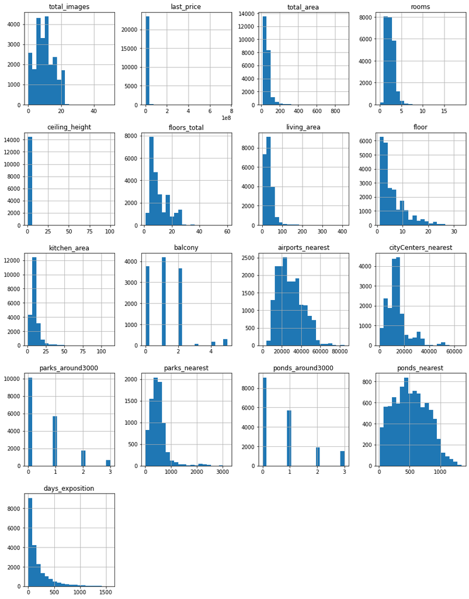

```python
#построение гистограмм по столбцам
df.hist(figsize=(15, 20), bins = 20)
```

# Выполните предобработку данных

```python
## определение пустот в стоблцах и подсчёт
print(df.isna().sum())
```

```
total_images                0
last_price                  0
total_area                  0
first_day_exposition        0
rooms                       0
ceiling_height           9195
floors_total               86
living_area              1903
floor                       0
is_apartment            20924
studio                      0
open_plan                   0
kitchen_area             2278
balcony                 11519
locality_name              49
airports_nearest         5542
cityCenters_nearest      5519
parks_around3000         5518
parks_nearest           15620
ponds_around3000         5518
ponds_nearest           14589
days_exposition          3181
dtype: int64
```

*Как видно, пропусков огромное количество, но пока неясна их природа, надо разложить и посчитать пропуски в столбцах сeiling_height 9195 floors_total 86 living_area 1903 is_apartment 20924 kitchen_area 2278 balcony 11519 locality_name 49 airports_nearest 5542 cityCenters_nearest 5519 parks_around3000 5518 parks_nearest 15620 ponds_around3000 5518 ponds_nearest 14589 days_exposition 3181

*Ошибки, скорей всего, связаны с неправильным или небрежным заполнением покупателями и продавцами, данные, полученные из ГИС-систем, склонен оценивать как достоверные - большое кол-во потребителей и проверяющих + более строгая система контроля.

*Описание столбцов согласно задания: airports_nearest — расстояние до ближайшего аэропорта в метрах (м) balcony — число балконов ceiling_height — высота потолков (м) cityCenters_nearest — расстояние до центра города (м) days_exposition — сколько дней было размещено объявление (от публикации до снятия) first_day_exposition — дата публикации floor — этаж floors_total — всего этажей в доме is_apartment — апартаменты (булев тип) kitchen_area — площадь кухни в квадратных метрах (м²) last_price — цена на момент снятия с публикации living_area — жилая площадь в квадратных метрах (м²) locality_name — название населённого пункта open_plan — свободная планировка (булев тип) parks_around3000 — число парков в радиусе 3 км parks_nearest — расстояние до ближайшего парка (м) ponds_around3000 — число водоёмов в радиусе 3 км ponds_nearest — расстояние до ближайшего водоёма (м) rooms — число комнат studio — квартира-студия (булев тип) total_area — общая площадь квартиры в квадратных метрах (м²) total_images — число фотографий квартиры в объявлении

```python
# вывод столбцов для наглядности
def descr(df):

    values = pd.DataFrame()

    for col in df.columns:
        values[col] = [df[col].unique(), df[col].dtypes, df[col].nunique()]

    return values.transpose().sort_values(by=1, ascending=True).rename(
        {0: 'значения', 1: 'тип данных', 2: 'кол-во уник значений'}, axis=1)
descr(df)
```

|  | значения | тип данных | кол-во уник значений |
| --- | --- | --- | --- |
| studio | [False, True] | bool | 2 |
| open_plan | [False, True] | bool | 2 |
| floor | [8, 1, 4, 9, 13, 5, 6, 22, 26, 7, 3, 2, 11, 15... | int64 | 33 |
| rooms | [3, 1, 2, 4, 5, 6, 0, 7, 11, 8, 14, 10, 15, 9,... | int64 | 17 |
| total_images | [20, 7, 10, 0, 2, 6, 5, 18, 9, 1, 16, 11, 8, 1... | int64 | 38 |
| ceiling_height | [2.7, nan, 3.03, 2.5, 2.67, 2.56, 3.05, 2.75, ... | float64 | 183 |
| ponds_around3000 | [2.0, 0.0, 3.0, 1.0, nan] | float64 | 4 |
| parks_nearest | [482.0, nan, 90.0, 84.0, 112.0, 310.0, 294.0, ... | float64 | 995 |
| parks_around3000 | [1.0, 0.0, 2.0, nan, 3.0] | float64 | 4 |
| cityCenters_nearest | [16028.0, 18603.0, 13933.0, 6800.0, 8098.0, na... | float64 | 7642 |
| airports_nearest | [18863.0, 12817.0, 21741.0, 28098.0, 31856.0, ... | float64 | 8275 |
| kitchen_area | [25.0, 11.0, 8.3, nan, 41.0, 9.1, 14.4, 18.9, ... | float64 | 971 |
| balcony | [nan, 2.0, 0.0, 1.0, 5.0, 4.0, 3.0] | float64 | 6 |
| ponds_nearest | [755.0, nan, 574.0, 234.0, 48.0, 553.0, 298.0,... | float64 | 1096 |
| total_area | [108.0, 40.4, 56.0, 159.0, 100.0, 30.4, 37.3, ... | float64 | 2182 |
| living_area | [51.0, 18.6, 34.3, nan, 32.0, 14.4, 10.6, 15.4... | float64 | 1782 |
| floors_total | [16.0, 11.0, 5.0, 14.0, 12.0, 26.0, 24.0, 27.0... | float64 | 36 |
| last_price | [13000000.0, 3350000.0, 5196000.0, 64900000.0,... | float64 | 2978 |
| days_exposition | [nan, 81.0, 558.0, 424.0, 121.0, 55.0, 155.0, ... | float64 | 1141 |
| first_day_exposition | [2019-03-07T00:00:00, 2018-12-04T00:00:00, 201... | object | 1491 |
| locality_name | [Санкт-Петербург, посёлок Шушары, городской по... | object | 364 |
| is_apartment | [nan, False, True] | object | 2 |

*булевы значения вопросов не вызывают, object тоже. rooms - в списке есть 17-комнатные квартиры? balcony - квартира с 5 балконами? или кто-то по ошибке забил площадь вместо числа?  
is_apartment - деление на жилое\нежилое? ошибки типа NaN - или пропуски, или ошибки в заполнении, или ошибки в типе данных?

*есть столбцы, где для упрощения жизни надо поменять тип данных

*в формат int из формата float: last_price floors_total balcony parks_around3000 parks_nearest ponds_around3000 ponds_nearest airports_nearest cityCenters_nearest days_exposition

*в bool из obj: is_apartment

*в date из obj: first_day_exposition object

*столбцы 'parks_around3000, 'ponds_around3000', 'cityCenters_nearest' написаны с нарушением стиля - надо причесать

*названия НП надо привести к общему знаменателю

**V2 Гистограмма была закомментирована внутри ветки кода. Перенёс в в отдельную графу выше, написал комментарий по отображаемым столбцам.

## Заполнение пропусков и исправление ошибок в столбцах

### переименованиие столбцов в snake_case, смена стиля

```python
df = df.rename(
    columns={'parks_around3000':'parks_around_3000',
             'ponds_around3000':'ponds_around_3000',
             'cityCenters_nearest':'city_centers_nearest'}
)
```

### проверка studio

```python
(df['studio']).describe()
```

```
count     23699
unique        2
top       False
freq      23550
Name: studio, dtype: object
```

```python
print('Ошибки до замены', df['studio'].isna().sum())
```

```
Ошибки до замены 0
```

- bool: квартира - студия или нет, ошибок нет, приведение не требуется

### проверка open_plan

```python
(df['open_plan']).describe()
```

```
count     23699
unique        2
top       False
freq      23632
Name: open_plan, dtype: object
```

```python
print('Ошибки до замены', df['open_plan'].isna().sum())
```

```
Ошибки до замены 0
```

- bool: планировка - свободная или нет, ошибок нет, приведение не требуется

### проверка floor

```python
(df['floor']).describe()
```

```
count    23699.000000
mean         5.892358
std          4.885249
min          1.000000
25%          2.000000
50%          4.000000
75%          8.000000
max         33.000000
Name: floor, dtype: float64
```

```python
print('Ошибки до замены', df['floor'].isna().sum())
```

```
Ошибки до замены 0
```

- float - этажность, 33 этажа максимум - правдоподобно, ошибок нет, приведение требуется

### проверка rooms

```python
df['rooms'].describe()
```

```
count    23699.000000
mean         2.070636
std          1.078405
min          0.000000
25%          1.000000
50%          2.000000
75%          3.000000
max         19.000000
Name: rooms, dtype: float64
```

- по логике, квартира с 0 комнат - это студия, где используется общее пространство. Для проверки:

```python
display(df[df['rooms'] == 0].head(5))
```

|  | total_images | last_price | total_area | first_day_exposition | rooms | ceiling_height | floors_total | living_area | floor | is_apartment | ... | kitchen_area | balcony | locality_name | airports_nearest | city_centers_nearest | parks_around_3000 | parks_nearest | ponds_around_3000 | ponds_nearest | days_exposition |
| --- | --- | --- | --- | --- | --- | --- | --- | --- | --- | --- | --- | --- | --- | --- | --- | --- | --- | --- | --- | --- | --- |
| 144 | 1 | 2450000.0 | 27.00 | 2017-03-30T00:00:00 | 0 | NaN | 24.0 | 15.50 | 2 | NaN | ... | NaN | 2.0 | посёлок Мурино | NaN | NaN | NaN | NaN | NaN | NaN | 181.0 |
| 349 | 4 | 2320000.0 | 25.00 | 2017-09-27T00:00:00 | 0 | NaN | 14.0 | 17.00 | 1 | NaN | ... | NaN | 0.0 | деревня Кудрово | NaN | NaN | NaN | NaN | NaN | NaN | 45.0 |
| 440 | 8 | 2480000.0 | 27.11 | 2018-03-12T00:00:00 | 0 | NaN | 17.0 | 24.75 | 4 | NaN | ... | NaN | 2.0 | Санкт-Петербург | 38171.0 | 15015.0 | 0.0 | NaN | 2.0 | 982.0 | 64.0 |
| 508 | 0 | 3375000.0 | 34.40 | 2017-03-28T00:00:00 | 0 | NaN | 26.0 | 24.30 | 19 | NaN | ... | NaN | 1.0 | посёлок Парголово | 53115.0 | 19292.0 | 0.0 | NaN | 1.0 | 593.0 | 430.0 |
| 608 | 2 | 1850000.0 | 25.00 | 2019-02-20T00:00:00 | 0 | NaN | 10.0 | NaN | 7 | NaN | ... | NaN | NaN | посёлок Шушары | NaN | NaN | NaN | NaN | NaN | NaN | 29.0 |

5 rows × 22 columns

```python
# назначение всем студиям признака "0 отдельных комнат"
df.loc[df['studio'] == True, 'rooms'] = 0
```

### проверка total_images

- кол-во фотографий в объявлении, на статистику не влияет, обработка не требуется

### проверка ceiling_height

```python
(df['ceiling_height']).describe()
```

```
count    14504.000000
mean         2.771499
std          1.261056
min          1.000000
25%          2.520000
50%          2.650000
75%          2.800000
max        100.000000
Name: ceiling_height, dtype: float64
```

```python
print('Ошибки до замены', df['ceiling_height'].isna().sum())
```

```
Ошибки до замены 9195
```

- есть явные ошибки, а также ошибки заполнения вроде потолков высотой 1 и 100 метров, в дальнейшем потребуется исправление

**V3, эта ошибка исправляется ниже, в блоке "6.6 высота потолков"

### проверка last_price

```python
(df['last_price']).describe()
display(df[df['last_price'] < 100000])
```

|  | total_images | last_price | total_area | first_day_exposition | rooms | ceiling_height | floors_total | living_area | floor | is_apartment | ... | kitchen_area | balcony | locality_name | airports_nearest | city_centers_nearest | parks_around_3000 | parks_nearest | ponds_around_3000 | ponds_nearest | days_exposition |
| --- | --- | --- | --- | --- | --- | --- | --- | --- | --- | --- | --- | --- | --- | --- | --- | --- | --- | --- | --- | --- | --- |
| 8793 | 7 | 12190.0 | 109.0 | 2019-03-20T00:00:00 | 2 | 2.75 | 25.0 | 32.0 | 25 | NaN | ... | 40.5 | NaN | Санкт-Петербург | 36421.0 | 9176.0 | 1.0 | 805.0 | 0.0 | NaN | 8.0 |

1 rows × 22 columns

- видимо, цену вносили не глядя, а имели ввиду цену в т.р., а не в р, ну, или кто-то баловался SEO. Замена вручную

```python
#df.loc[8793, 'last_price'] = 12190000
```

***V3, удаление строки и повторная проверка

```python
df.drop(index=8793, inplace = True)
```

```python
display(df[df['last_price'] < 100000])
```

|  | total_images | last_price | total_area | first_day_exposition | rooms | ceiling_height | floors_total | living_area | floor | is_apartment | ... | kitchen_area | balcony | locality_name | airports_nearest | city_centers_nearest | parks_around_3000 | parks_nearest | ponds_around_3000 | ponds_nearest | days_exposition |
| --- | --- | --- | --- | --- | --- | --- | --- | --- | --- | --- | --- | --- | --- | --- | --- | --- | --- | --- | --- | --- | --- |

0 rows × 22 columns

### проверка floors_total

```python
#floors_total
df['floors_total'].describe()
```

```
count    23612.000000
mean        10.673217
std          6.596654
min          1.000000
25%          5.000000
50%          9.000000
75%         16.000000
max         60.000000
Name: floors_total, dtype: float64
```

```python
print('Ошибки до замены', df['floors_total'].isna().sum())
```

```
Ошибки до замены 86
```

- 86 ошибок, опять же - выяснить без привязки к БТИ ничего нельзя, поэтому эти строки сбрасываются

```python
df = df.dropna(subset=['floors_total'])
print('Ошибки после замены', df['floors_total'].isna().sum())
```

```
Ошибки после замены 0
```

### проверка balcony

- балкон увеличивает цену квартиры, если балкон явно не указан - его нет, тогда эти ячейки заполняются нулями

```python
print('Ошибки до замены', df['balcony'].isna().sum())
df['balcony'] = df['balcony'].fillna(0)
print('Ошибки после замены', df['balcony'].isna().sum())
```

```
Ошибки до замены 11479
Ошибки после замены 0
```

### проверка parks_around_3000

```python
#число парков в радиусе 3 км
(df['parks_around_3000']).describe()
```

```
count    18104.000000
mean         0.611412
std          0.802185
min          0.000000
25%          0.000000
50%          0.000000
75%          1.000000
max          3.000000
Name: parks_around_3000, dtype: float64
```

- т.к. наличие парка повышает цену квартиры, продавец будет явно указывать расстояние до парка, отсюда - значение 0 означает отсуствие парка. Квартиры прямо в парке есть (та же Удельная или Сосновка), но их исчезающе малое значение. Все пропуски забить нулями

```python
df.loc[df['parks_around_3000'].isna(), 'parks_around_3000'] = 0
```

### проверка parks_nearest

**V4

```python
#расстояние до ближайшего парка (м)
print('Ошибки до замены', df['parks_nearest'].isna().count())
```

```
Ошибки до замены 23612
```

### проверка ponds_around_3000

- логика и исполнение аналогично parks_around_3000

```python
df.loc[df['ponds_around_3000'].isna(), 'ponds_around_3000'] = 0
```

### проверка ponds_nearest

**v4

```python
#расстояние до ближайшего пруда (м)
print('Ошибки до замены', df['ponds_nearest'].isna().sum())
```

```
Ошибки до замены 14551
```

### проверка airports_nearest

**V4

- будем считать, что если аэропорт не указан, то находится за пределами СПб настолько далеко, что эта цифра теряет значение

```python
print('Ошибки до замены', df['airports_nearest'].isna().sum())
```

```
Ошибки до замены 5532
```

### проверка locality_name

```python
df['locality_name'].describe()
```

```
count               23564
unique                364
top       Санкт-Петербург
freq                15650
Name: locality_name, dtype: object
```

- строковый формат, названия НП, идёт поиск пропущенных

```python
df['locality_name'].isna().sum()
```

```
48
```

- 48 пропусков, индексов и геодат нет, пропуски удаляются

```python
df = df.dropna(subset=['locality_name'])
```

- проверка на уникальные названия

```python
print(df['locality_name'].unique())
```

```
['Санкт-Петербург' 'посёлок Шушары' 'городской посёлок Янино-1'
 'посёлок Парголово' 'посёлок Мурино' 'Ломоносов' 'Сертолово' 'Петергоф'
 'Пушкин' 'деревня Кудрово' 'Коммунар' 'Колпино'
 'поселок городского типа Красный Бор' 'Гатчина' 'поселок Мурино'
 'деревня Фёдоровское' 'Выборг' 'Кронштадт' 'Кировск'
 'деревня Новое Девяткино' 'посёлок Металлострой'
 'посёлок городского типа Лебяжье' 'посёлок городского типа Сиверский'
 'поселок Молодцово' 'поселок городского типа Кузьмоловский'
 'садовое товарищество Новая Ропша' 'Павловск' 'деревня Пикколово'
 'Всеволожск' 'Волхов' 'Кингисепп' 'Приозерск' 'Сестрорецк'
 'деревня Куттузи' 'посёлок Аннино' 'поселок городского типа Ефимовский'
 'посёлок Плодовое' 'деревня Заклинье' 'поселок Торковичи'
 'поселок Первомайское' 'Красное Село' 'посёлок Понтонный' 'Сясьстрой'
 'деревня Старая' 'деревня Лесколово' 'посёлок Новый Свет' 'Сланцы'
 'село Путилово' 'Ивангород' 'Мурино' 'Шлиссельбург' 'Никольское'
 'Зеленогорск' 'Сосновый Бор' 'поселок Новый Свет' 'деревня Оржицы'
 'деревня Кальтино' 'Кудрово' 'поселок Романовка' 'посёлок Бугры'
 'поселок Бугры' 'поселок городского типа Рощино' 'Кириши' 'Луга'
 'Волосово' 'Отрадное' 'село Павлово' 'поселок Оредеж' 'село Копорье'
 'посёлок городского типа Красный Бор' 'посёлок Молодёжное' 'Тихвин'
 'посёлок Победа' 'деревня Нурма' 'поселок городского типа Синявино'
 'Тосно' 'посёлок городского типа Кузьмоловский' 'посёлок Стрельна'
 'Бокситогорск' 'посёлок Александровская' 'деревня Лопухинка' 'Пикалёво'
 'поселок Терволово' 'поселок городского типа Советский' 'Подпорожье'
 'посёлок Петровское' 'посёлок городского типа Токсово' 'поселок Сельцо'
 'посёлок городского типа Вырица' 'деревня Кипень' 'деревня Келози'
 'деревня Вартемяги' 'посёлок Тельмана' 'поселок Севастьяново'
 'городской поселок Большая Ижора' 'городской посёлок Павлово'
 'деревня Агалатово' 'посёлок Новогорелово'
 'городской посёлок Лесогорский' 'деревня Лаголово' 'поселок Цвелодубово'
 'поселок городского типа Рахья' 'поселок городского типа Вырица'
 'деревня Белогорка' 'поселок Заводской' 'городской посёлок Новоселье'
 'деревня Большие Колпаны' 'деревня Горбунки' 'деревня Батово'
 'деревня Заневка' 'деревня Иссад' 'Приморск'
 'городской посёлок Фёдоровское' 'деревня Мистолово' 'Новая Ладога'
 'поселок Зимитицы' 'поселок Барышево' 'деревня Разметелево'
 'поселок городского типа имени Свердлова' 'деревня Пеники'
 'поселок Рябово' 'деревня Пудомяги' 'поселок станции Корнево'
 'деревня Низино' 'деревня Бегуницы' 'посёлок Поляны'
 'городской посёлок Мга' 'поселок Елизаветино'
```

[output cut: 72 more lines]

```
 'поселок городского типа Большая Ижора' 'поселок Кирпичное'
 'деревня Ям-Тесово' 'деревня Раздолье' 'деревня Терпилицы'
 'поселок городского типа Токсово' 'посёлок Шугозеро' 'деревня Ваганово'
 'поселок Пушное' 'садовое товарищество Садко' 'посёлок Усть-Ижора'
 'деревня Выскатка' 'городской посёлок Свирьстрой' 'поселок Громово'
 'деревня Кисельня' 'посёлок Старая Малукса' 'деревня Трубников Бор'
 'поселок Калитино' 'посёлок Высокоключевой'
 'садовое товарищество Приладожский' 'посёлок Пансионат Зелёный Бор'
 'деревня Ненимяки' 'поселок Пансионат Зелёный Бор' 'деревня Снегирёвка'
 'деревня Рапполово' 'деревня Пустынка' 'поселок Рабитицы'
 'деревня Большой Сабск' 'деревня Русско' 'деревня Лупполово'
 'деревня Большое Рейзино' 'деревня Малая Романовка' 'поселок Дружноселье'
 'поселок Пчевжа' 'поселок Володарское' 'деревня Нижняя'
 'коттеджный посёлок Лесное' 'деревня Тихковицы' 'деревня Борисова Грива'
 'посёлок Дзержинского']
```

- т.к. есть длинные наименования НП, и разные названия одних и тех же категорий (посёлок, городской посёлок), а так же разные написания одной и той же категории (поселок - посёлок), надо привести всё к единому образцу

```python
np = ['поселок ', 'городского типа ', 'городской ',  'деревня ',
                'коттеджный ', 'село ', 'посёлок ', 'при железнодорожной станции ',
                'станции ', 'садоводческое некоммерческое товарищество ', 'садовое товарищество ']
for value in np:
    df['locality_name'] = df['locality_name'].str.replace(value, '')
```

```python
# замена всех "Ё" на "Е"
def e_replacing(text):
    text = text.replace('ё', 'е')
    list =['деревня ', 'коттеджный поселок ', 'садовое товарищество ', 'поселок городского типа ',
           'поселок при железнодорожной станции ', 'поселок станции ',
           'городской поселок ', 'садоводческое некоммерческое товарищество '
           'посёлок городского типа ', 'поселок имени', 'поселок ', 'село ']
    for i in list:
        text = text.replace(i, '')
    return text
```

Причины ошибок - человеческий фактор, устаревшая документация, различные бюрократические и ведомственные традиции заполнения документов

### проверка city_centers_nearest

**V4

```python
#проверка на кол-во ошибок
print('Ошибки до замены', df['city_centers_nearest'].isna().sum())
```

```
Ошибки до замены 5501
```

```python
# приведение метров в километры
df['city_center_km'] = df['city_centers_nearest']/1000
```

```python
#pivot_table_km = df.query('locality_name == "Санкт-Петербург" and city_center_km !=999999999').pivot_table(index = 'city_center_km', values = 'last_price', aggfunc = 'median')
#pivot_table_km.plot()
```

```python
#df_temp = df.query("city_centers_nearest == city_centers_nearest")
```

```python
#def refilling (col_na, col_group):
    #for value in df[col_group].unique():
        #median_col_group = df.loc[df[col_group]==value, col_na].median()
        #df.loc[(df[col_na].isna()) & (df[col_group]==value), col_na] = median_col_group
```

```python
#refilling('city_centers_nearest', 'locality_name')
```

- создание списка НП, которые по факту являются СПб, а по бумагам проходят как отдельные образования, и вычисление медианы для всего этого большого Питера с заполнением пропусков в нём же

```python
# V4
spb_cities = ['Санкт-Петербург', 'Колпино', 'Левашово', 'Металлострой', 'Парголово', 'Петро-Славянка', 'Усть-Ижора',
              'Шушары', 'Янино-1', 'Новое Девяткино', 'Кудрово', 'Всеволожск', 'Мурино', 'Бугры', 'Заневка']
# добавление столбца на основе этого списка
df['big_spb'] = df['locality_name'].isin(spb_cities)
```

```python
#V4
#создание столбца с заполненными медианными данными для фактического СПб
df['city_center_mod'] = (
    df[df['big_spb'] == True].groupby('big_spb')['city_center_km'].apply(lambda x: x.fillna(x.median()))
)
```

```python
#V4
#расстояние до центра СПб по медиане для "пустышек", округление до целых км
df['city_center_mod'] = df['city_center_mod'].round(0)
```

**V3, перенос из блока ниже

### проверка kitchen_area

```python
print(df['kitchen_area'].describe())
print('Ошибки до замены', df['kitchen_area'].isna().sum())
```

```
count    21342.000000
mean        10.559591
std          5.897208
min          1.300000
25%          7.000000
50%          9.100000
75%         12.000000
max        112.000000
Name: kitchen_area, dtype: float64
Ошибки до замены 2222
```

- Так как в квартирах-студиях отдельных кухонь нет, то студиям назначается нулевая площадь кухни

```python
df.loc[df['studio'] == True, 'kitchen_area'] = 0
```

- Оставшиеся ошибки площадь кухонь заполняю по схеме жилой площади с медианой

```python
for i in range(1, df['rooms'].max()):
    koef = (df[df['rooms'] == i]['kitchen_area'] / df[df['rooms'] == i]['total_area']).median()
    df['kitchen_area'] = df['kitchen_area'].fillna(value = df['total_area'] * koef)
```

**V3, перенос из блока ниже

### проверка living_area

```python
print('Ошибки до замены', df['living_area'].isna().sum())
```

```
Ошибки до замены 1865
```

- Лучше всего ошибки заполнить медианным значением площади относительно количества комнат, т.е. нужна будет обработка:
1. вычислить мед для каждой пропущенной квартиры (жил площ / кол-во комнат по медиане)
2. записать полученное уникальное значение для каждого пропуска в его же уникальную ячейку

```python
#заполнение пропусков в living_area
for i in range(0, df['rooms'].max()):
    koef = (df[df['rooms'] == i]['living_area'] / df[df['rooms'] == i]['total_area']).median()
    df['living_area'] = df['living_area'].fillna(value = df['total_area'] * koef)
#есть совпадения общей и жилой площади, нужна доппроверка - превышение жилой над общей и группировка по столбцу общей площади
print(df.query('living_area > total_area')['living_area'].count())
```

```
0
```

### проверка days_exposition

- построение графика для понимания распределения ошибок дата\кол-во

```python
print('Ошибки до замены', df['days_exposition'].isna().sum())
```

```
Ошибки до замены 3171
```

- преобразование в date из obj, так как для времени размещения это соотвествующий формат

```python
df['first_day_exposition'] = pd.to_datetime(df['first_day_exposition'], format='%Y-%m-%dT%H:%M:%S')
```

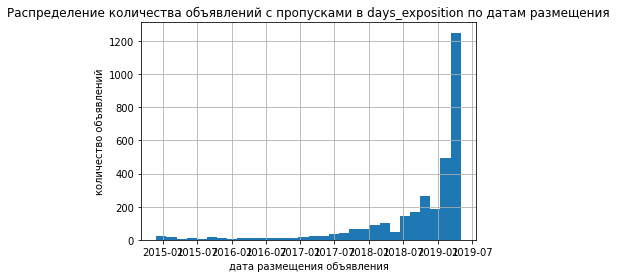

```python
# переменная для работы без затрагивания мейн фрейма
day_n = df.query('days_exposition.isna()')

#гистограмма по дате размещения объявлений:
day_n['first_day_exposition'].hist(bins=30).set(xlabel = 'дата размещения объявления',
                              ylabel = 'количество объявлений',
                             title ='Распределение количества объявлений с пропусками в days_exposition по датам размещения');
```

Наибольшее количество пропусков в гистограмме скопилось в конце, из чего следует, что эти объявления висят в статусе "не продано" или "не снято". Раз уж они существуют в базе на момент выгрузки, то можно предположить, что количеством дней days_exposition будет разница first_day_exposition и максимальной датой в днях

```python
#максимальная дата в днях
max_dt = df['first_day_exposition'].max()

#заполнение пропусков разностью first_day_exposition и max_dt:
df.loc[df['days_exposition'].isna(), 'days_exposition'] = (max_dt - df.loc[df['days_exposition'].isna(),
                                                                           'first_day_exposition']).dt.days
```

**V3 locality_name перенёс выше, перед city_centers

### проверка is_apartment

```python
(df['is_apartment']).describe()
```

```
count      2760
unique        2
top       False
freq       2710
Name: is_apartment, dtype: object
```

- проверка на соответствие категории "апартаменты", требуется приведение в булев тип, есть ошибки типа NaN

```python
df['is_apartment'] = df['is_apartment'].fillna(False)
```

- апартаменты явно снижают стоимость объекта, т.к. не являются полноценной жилой недвижимостью, поэтому все NaN нужно перевести в False, по умолчанию все объекты считаются жилыми

```python
print('Пропусков после замены', df['is_apartment'].isna().sum())
```

```
Пропусков после замены 0
```

### преобразование для необходимого там, где нельзя использовать дробные значения (например, 3.2 балкона), и достаточного там, где хватает круглых значений (цены в рублях без копеек или дистанции в километрах без метров)

```python
# точность до копеек не нужна
df['last_price'] = df['last_price'].astype('int64')
```

```python
# 3.5 этажа - это самострой
df['floors_total'] = df['floors_total'].astype('int64')
```

```python
df['floor'] = df['floor'].astype('int64')
```

```python
# и 3.5 комнаты - это самострой
df['rooms'] = df['rooms'].astype('int64')
```

```python
# и 3.5 балкона - тоже
df['balcony'] = df['balcony'].astype('int64')
```

```python
# для дат размещения есть дни, всё что меньше, для нас не важно
df['days_exposition'] = df['days_exposition'].astype('int64')
```

```python
# геодезическая точность не нужна
df['parks_around_3000'] = df['parks_around_3000'].astype('int64')
```

```python
# аналогично по всем остальным
df['parks_nearest'] = df['parks_nearest'].dropna().astype('int64')
```

```python
df['ponds_around_3000'] = df['ponds_around_3000'].astype('int64')
```

```python
df['ponds_nearest'] = df['ponds_nearest'].dropna().astype('int64')
```

```python
df['airports_nearest'] = df['airports_nearest'].dropna().astype('int64')
```

```python
#перевод расстояний до центра
df['city_centers_nearest'] = df['city_centers_nearest'].dropna().astype('int64')
```

```python
df.info()
```

```
<class 'pandas.core.frame.DataFrame'>
Int64Index: 23564 entries, 0 to 23698
Data columns (total 25 columns):
 #   Column                Non-Null Count  Dtype
---  ------                --------------  -----
 0   total_images          23564 non-null  int64
 1   last_price            23564 non-null  int64
 2   total_area            23564 non-null  float64
 3   first_day_exposition  23564 non-null  datetime64[ns]
 4   rooms                 23564 non-null  int64
 5   ceiling_height        14480 non-null  float64
 6   floors_total          23564 non-null  int64
 7   living_area           23564 non-null  float64
 8   floor                 23564 non-null  int64
 9   is_apartment          23564 non-null  bool
```

[output cut: 17 more lines]

**V6 Промежуточные выводы после предобработки

Было произведено переименование столбцов для лучшего чтения и приведения их в единиый стиль, что облегчит дальнейшую работу. Строки, которые можно выбросить из фрейма без жальнейшего ущерба для анализа - единичные случаи, явно выделяющиеся из общего ряда, были удалены. Столбцы были проверены на наличие ошибок и пропусков, в тех случаях, где моно было заполнить пропуски на основании имеющихся данных, это было сделано с помощью медианных значений, там, где исходя из логики можно было явно указать значение, как в df['studio'], это было проведено.

Наименования населённых пунктов были приведены к единообразию для удобства дальнейшей работы - типы и написания типов были стандартизированы.

Дата была привезена к удобочитаемому стандарту, стоблцы, содержащие неверный формат, или для которых можно выбрать более удобный формат, например df['balcony'], так как балкон не может быть дробным числом, были переведены в другие типы данных (целочисленные).

Пропуски и ошибки в наибольшей степени образованы из-за человеческого фактора, влияние ГИС минимально, в дальнейшем стоит рассмотреть системы контроля заполнения и запрет на ввод заведомо ложных данных, как потолок 100 метров высотой.

# Добавьте в таблицу новые столбцы со следующими параметрами:

## цена одного квадратного метра (нужно поделить стоимость объекта на его общую площадь, а затем округлить до двух знаков после запятой)

```python
df['per_sq_meter'] = (df['last_price'] / df['total_area']).round(2)
```

## день недели публикации объявления (0 — понедельник, 1 — вторник и так далее)

```python
# даты публикаций
# добавление дня публикации объявления
df['weekday_exposition'] = df['first_day_exposition'].dt.weekday
#добавление месяца публикации объявления
df['month_exposition'] = df['first_day_exposition'].dt.month
#добавление года публикации объявления
df['year_exposition'] = df['first_day_exposition'].dt.year
```

## тип этажа квартиры (значения — «первый», «последний», «другой»)

- перевод множества этажей в 3 категории

```python
#функция, этаж
def floors_category(row):
    if row['floor'] == 1:
        return 'первый'
    elif row['floor'] == row['floors_total']:
        return 'последний'
    else:
        return 'другой'

df['floor_group'] = df.apply(floors_category, axis=1)
```

## расстояние до центра города в километрах (переведите из м в км и округлите до ближайших целых значений)

```python
df['city_centers_nearest'] = (df['city_centers_nearest'] / 1000).round(2)
```

**V3 перенёс в блок выше

```python
#соотношение жилой к общей площади living_area_ratio
df['living_area_ratio'] = df['living_area'] / df['total_area']
#соотношение кухни к общей площади kitchen_area_ratio
df['kitchen_area_ratio'] = df['kitchen_area'] / df['total_area']
```

```python
# обновлённая таблица для поиска связей в соотношении площадей внутри квартиры
df[['total_area', 'living_area', 'living_area_ratio','kitchen_area','kitchen_area_ratio']].describe()
```

|  | total_area | living_area | living_area_ratio | kitchen_area | kitchen_area_ratio |
| --- | --- | --- | --- | --- | --- |
| count | 23564.000000 | 23564.000000 | 23564.000000 | 23564.000000 | 23564.000000 |
| mean | 60.320758 | 35.180883 | 0.574730 | 10.844120 | 0.191496 |
| std | 35.656406 | 23.031557 | 0.106408 | 6.550570 | 0.073106 |
| min | 12.000000 | 2.000000 | 0.021583 | 0.000000 | 0.000000 |
| 25% | 40.000000 | 19.000000 | 0.500000 | 7.100000 | 0.136115 |
| 50% | 52.000000 | 30.305000 | 0.580645 | 9.415606 | 0.180975 |
| 75% | 69.700000 | 42.900000 | 0.659091 | 12.000000 | 0.247779 |
| max | 900.000000 | 434.457020 | 1.000000 | 123.889556 | 0.787879 |

# Проведение исследовательского анализа данных:

## Список исследуемых параметров:

```
общая площадь;
жилая площадь;
площадь кухни;
цена объекта;
количество комнат;
высота потолков;
тип этажа квартиры («первый», «последний», «другой»);
общее количество этажей в доме;
расстояние до центра города в метрах;
расстояние до ближайшего парка

уборка ошибок и выбросов, гистограммы, аналитика и комментарии
```

### общая площадь

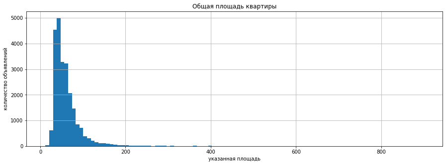

```python
df['total_area'].hist(bins=100, figsize=(15,5)).set(xlabel = 'указанная площадь', ylabel = 'количество объявлений', title ='Общая площадь квартиры');
```

- квартиры ниже 20 бывают, но это или комнаты, или нежилые помещения (кладовки), а квартиры 100 м и более представляют исчезающее малое значение, поэтому график нагляднее обрезать

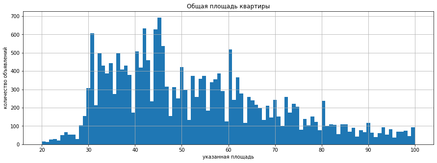

```python
df['total_area'].hist(bins=100, range=(20, 100), figsize=(15,5)).set(xlabel = 'указанная площадь', ylabel = 'количество объявлений', title ='Общая площадь квартиры');
```

Пиковые значения - 30, 45 и 60, соотвествующие основным типам - 1, 2 и 3-хкомнатным квартирам, меньшие пики на 80, 90, 100 - соотвествуют более редким 4-7комннатным квартирам либо срезу жилья комфорт и премкласса. Ошибок и аномалий на графике нет.

### жилая площадь

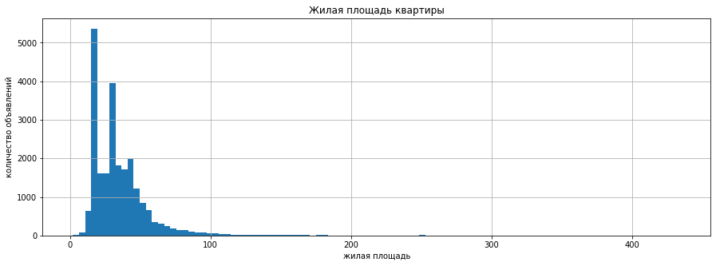

```python
df['living_area'].hist(bins=100, figsize=(15,5)).set(xlabel = 'жилая площадь', ylabel = 'количество объявлений', title ='Жилая площадь квартиры');
```

Как видно, жилая площадь имеет пики в районе 20, 30 и 40 кв м, после 50 кв м площади резко падают, нужен более детальный график

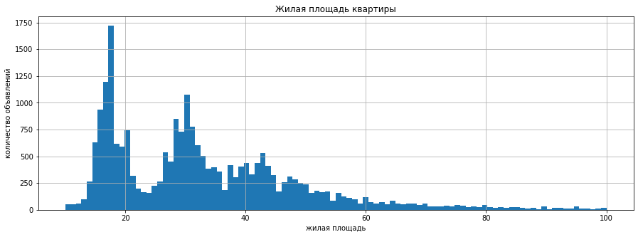

```python
df['living_area'].hist(bins=100, range=(10, 100), figsize=(15,5)).set(xlabel = 'жилая площадь', ylabel = 'количество объявлений', title ='Жилая площадь квартиры');
```

Пиковые значения - 15, 30 и 45, соотвествующие основным типам - 1, 2 и 3-хкомнатным квартирам, меньшие пики на 50, 60, 80 - соотвествуют более редким 4-7комннатным квартирам либо срезу жилья комфорт и премкласса. Ошибок и аномалий на графике нет.

### площадь кухни

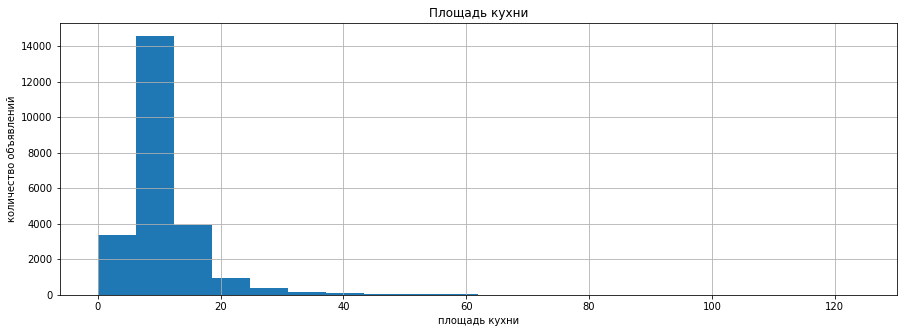

```python
df['kitchen_area'].hist(bins=20, figsize=(15,5)).set(xlabel = 'площадь кухни', ylabel = 'количество объявлений', title ='Площадь кухни');
```

- после 30 кв м площадь стремится к нулю, количество этих значений невелико, нужно уточнение графика

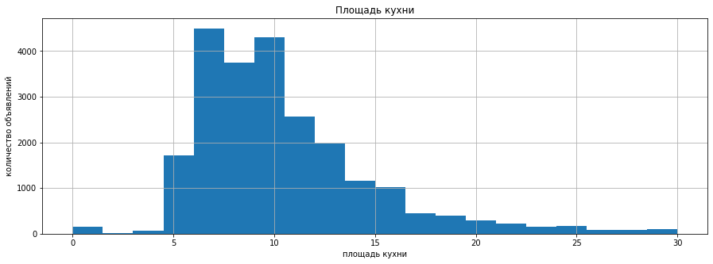

```python
df['kitchen_area'].hist(bins=20, range = (0, 30), figsize=(15,5)).set(xlabel = 'площадь кухни', ylabel = 'количество объявлений', title ='Площадь кухни');
```

Основная масса кухонь - около 7 кв м,затем 10 и 15 кв м, что соотвествует массе 1-2-3 комнатных квартир из исследования выше. Ошибок и аномалий на графике нет.

### цена объекта

```python
print('Ошибки до замены', df['last_price'].isna().sum())
print(df['last_price'].max())
```

```
Ошибки до замены 0
763000000
```

- Ошибок нет, видимо, к деньгам люди относятся наиболее внимательно, нежели к заполнению прочих параметров, максимальная цена 763 млн руб

```python
df[df['last_price'] == 763000000]
```

|  | total_images | last_price | total_area | first_day_exposition | rooms | ceiling_height | floors_total | living_area | floor | is_apartment | ... | city_center_km | big_spb | city_center_mod | per_sq_meter | weekday_exposition | month_exposition | year_exposition | floor_group | living_area_ratio | kitchen_area_ratio |
| --- | --- | --- | --- | --- | --- | --- | --- | --- | --- | --- | --- | --- | --- | --- | --- | --- | --- | --- | --- | --- | --- |
| 12971 | 19 | 763000000 | 400.0 | 2017-09-30 | 7 | NaN | 10 | 250.0 | 10 | False | ... | 3.956 | True | 4.0 | 1907500.0 | 5 | 9 | 2017 | последний | 0.625 | 0.247779 |

1 rows × 32 columns

- Объект площадью 400 кв м, всего с 7 комнатами и за 763 млн руб. Явно уникальное значение, можно выбросить из графика и взять меньший масштаб

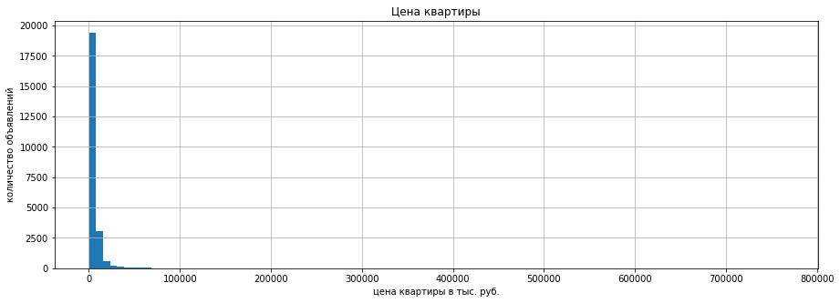

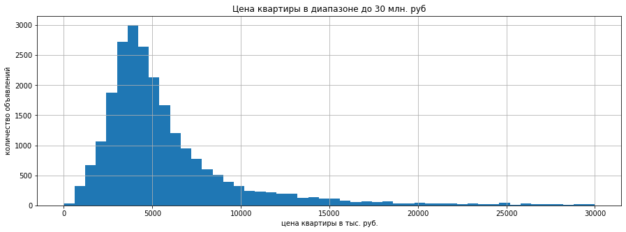

```python
# общее преставление цен
(df['last_price']/1000).hist(bins=100, figsize=(15,5)).set(xlabel = 'цена квартиры в тыс. руб.', ylabel = 'количество объявлений', title = 'Цена квартиры');
plt.show()

# как видно, основное распередение идёт на диапазон 0-30 млн, поэтому график надо детализировать
(df['last_price']/1000).hist(bins=50, figsize=(15,5), range=(0, 30000)).set(xlabel = 'цена квартиры в тыс. руб.', ylabel = 'количество объявлений', title = 'Цена квартиры в диапазоне до 30 млн. руб');
```

Цены сгруппированы в районе пика в 3.5 млн, что соотвествует квартирам эконом-класса, с плавным убывание после 5.5 млн руб, что является отсекающей ценой. После 15 млн график стремится к нулю, и количество таких квартир не оказывает существенного давления на весь прочий рынок.

### количество комнат

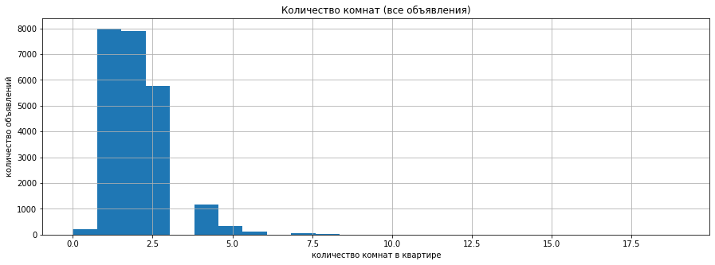

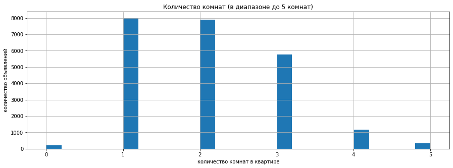

```python
# общая гистограмма по количеству комнат в квартире:
df['rooms'].hist(bins=25, figsize=(15,5)).set(title='Количество комнат (все объявления)',
    xlabel='количество комнат в квартире', ylabel='количество объявлений');
plt.show()

#гистограмма выборки (в диапазоне до 6 комнат )
df['rooms'].hist(bins=25, range=(0, 5), figsize=(15,5)).set(title='Количество комнат (в диапазоне до 5 комнат)',
    xlabel='количество комнат в квартире', ylabel='количество объявлений');
```

График уточняет прежние положения - по популярности идут одно-, двух- и трёхкомнатные квартиры, а вот студий продаётся весьма небольшое значение. Можно предположить, что рынок уже не потребляет самый дешёвый сегмент, и кривая спроса потихоньку смещается в более комфортные сегменты жилья. "Жить стало лучше, жить стало веселей!"

Квартира с 19 комнатами - уникум, и, по хорошему, должна находиться в отдельной базе.

### высота потолков

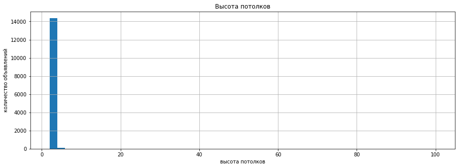

```python
df['ceiling_height'].hist(bins=50, range=(2, 100), figsize=(15,5)).set(title='Высота потолков',
    xlabel='высота потолков', ylabel='количество объявлений');
```

- Так как встретить потолки выше 4 м почти нереально - не считая редкие двухуровневые квартиры, дома типа "геокупол" или бывшие дворцы аристократии, то график лучше уточнить

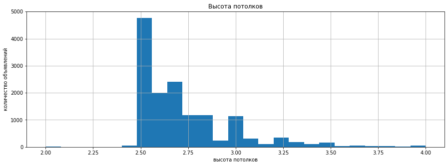

```python
df['ceiling_height'].hist(bins=25, range=(2, 4), figsize=(15,5)).set(title='Высота потолков',
    xlabel='высота потолков', ylabel='количество объявлений');
```

```python
df['ceiling_height'].describe()
```

```
count    14480.000000
mean         2.771285
std          1.262026
min          1.000000
25%          2.510000
50%          2.650000
75%          2.800000
max        100.000000
Name: ceiling_height, dtype: float64
```

- потолки высотой 1 и 100 метров - явные ошибки, которые будут перезаписаны либо сброшены

```python
print('Ошибки до замены', df['ceiling_height'].isna().sum())
```

```
Ошибки до замены 9084
```

- Сперва надо убрать сверхвысокие потолки, возникшие из-за ошибки ввода в запятой, поэтому такие значения надо делить на 10 и перезаписывать

```python
df.loc[(df['ceiling_height'] >= 20) & (df['ceiling_height'] <= 32), 'ceiling_height'] = df['ceiling_height'] / 10
```

- и множество пропусков. В идеале заполнять их надо так: делать запрос в БТИ через API по индексу дома для получения высоты из техпаспорта, но такой возможности у меня нет, поэтому будет заполнение медианой

```python
df['ceiling_height'] = df['ceiling_height'].fillna(df['ceiling_height'].median())
```

- квартиры с потолками 1 и 100 метров существуют в единственном экземпляре, поэтому они удаляются

```python
df[df['ceiling_height'] == 100] = df.dropna(subset=['ceiling_height'])
```

```python
df[df['ceiling_height'] == 1] = df.dropna(subset=['ceiling_height'])
```

Исходя из первого графика предполагаем, что все потолки находятся в диапазоне до 4 м.

Прочие высоты по возрастанию: "сталинки", премиум-класс, дореволюционные квартиры - весьма небольшая часть рынка, на общую картину не влияет.

Квартиры со значением выше 4м относятся или к очень редким квартирам свободной планировки, квартирам на последних этажах со стеклянными куполами вместо крыши (как в районе Дворцовой набережной), или являются ошибкой заполнения (как пресловутая квартира с потолком 100 метров).

### тип этажа квартиры

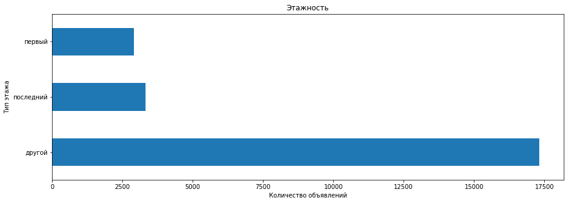

```python
# горизонтальная гистограмма для каждого типа этажей
plotdata = df['floor_group'].value_counts()
plotdata.plot(kind='barh', figsize=(15, 5))
plt.title('Этажность')
plt.ylabel('Тип этажа')
plt.xlabel('Количество объявлений')
```

```python
print(df['floor_group'].unique())
```

```
['другой' 'первый' 'последний']
```

Основная масса сделок приходится на средние этажи, первый и последний традиционно непопулярны.

### общее количество этажей в доме

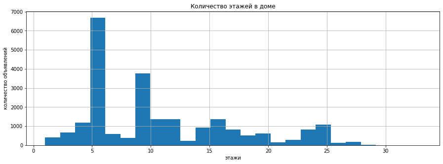

```python
df['floors_total'].hist(bins=25, range=(1, 33), figsize=(15,5)).set(title='Количество этажей в доме',
    xlabel='этажи', ylabel='количество объявлений');
```

### расстояние до центра города в метрах

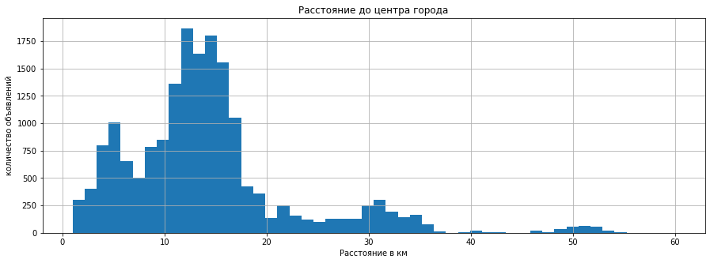

```python
## V3
df['city_centers_nearest'].hist(bins=50, range=(1, 60), figsize=(15,5)).set(title='Расстояние до центра города',
    xlabel='Расстояние в км', ylabel='количество объявлений');
```

Основная масса предложений находится на расстоянии 12-15 км от центра города, после 30 км (в пределах городов-спутников вроде Стрельны или Всеволожcка) количество предложений падает до околонулевых значений.

### расстояние до ближайшего парка

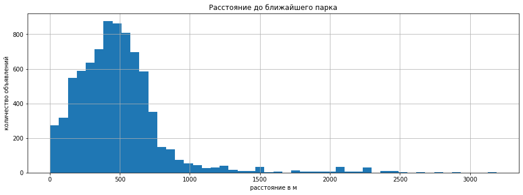

```python
df['parks_nearest'].hist(bins=50, figsize=(15,5)).set(title='Расстояние до ближайшего парка',
    xlabel='расстояние в м', ylabel='количество объявлений');
```

```python
#V4
print('Квартиры без парков:', df['parks_nearest'].isna().sum())
```

```
Квартиры без парков: 15535
```

**V4

## Изучение скорости продажи квартир

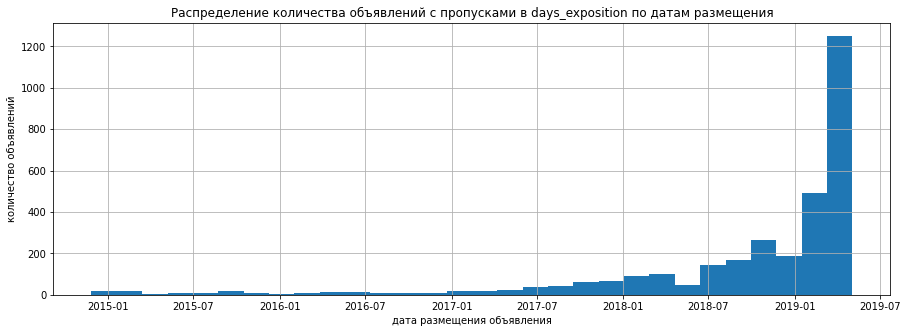

```python
#гистограмма по дате размещения объявлений:
day_n['first_day_exposition'].hist(bins=30, figsize=(15, 5)).set(xlabel = 'дата размещения объявления',
                              ylabel = 'количество объявлений',
                             title ='Распределение количества объявлений с пропусками в days_exposition по датам размещения');
```

Наибольшее количество пропусков в гистограмме скопилось в конце, из чего следует, что эти объявления висят в статусе "не продано" или "не снято".

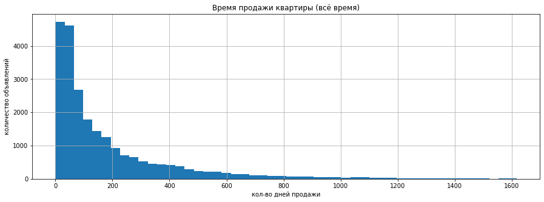

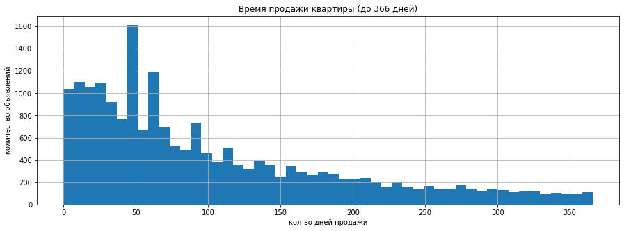

```python
#общая гистограмма времени продажи квартиры:
df['days_exposition'].hist(bins=50, figsize=(15, 5)).set(title='Время продажи квартиры (всё время)',
    xlabel='кол-во дней продажи', ylabel='количество объявлений');
plt.show()

# общая гистограмма по срезу времени продажи до 400 дней:
df['days_exposition'].hist(bins=50, range=(0, 366), figsize=(15, 5)).set(
    title='Время продажи квартиры (до 366 дней)',
    xlabel='кол-во дней продажи', ylabel='количество объявлений');
```

Основной пик продажи квартир приходится первые 60 дней, второй - на вторые 60, третий - на третьи 60. Такое плавное снижение со смещением свидетельствует о том, что рынок является "рынком продавца", а покупатели берут квартиры несмотря на цену. Рынок находится в стадии перегрева, спрос обеспечивается неуверенностью людей в завтрашнем дне, желанием сохранить деньги в "бетоне" и подпитывается дешёвыми деньгами в виде льготных ипотечных кредитов.

Второй график с пиком в районе 50 дней подтверждает, что основная масса покупателей приходит через ипотечный институт - как раз на due diligence у банков и уходит от 45 до 60 дней (по личному опыту), с принятием решения, резервированием средств и оформление бумаг. Вторые пики до 25 дней - это покупки "за наличные", когда вся сумма есть на руках или на банковском счёте. Такие сделки совершаются в период от 5 до 15, реже 20 дней (по личному опыту).

К необычно долгим продажам относятся продажи от 800 до 1600 дней, что можно отнести или к невероятной жадности продавца, или очень низкой или наоборот - очень высокой ценности квартиры. *(коммуналка с алкашами никому не нужна, а на квартиру в Смольном не у всякого есть деньги)

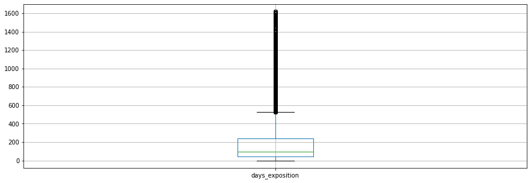

```python
# построение ящичной диаграммы
df.boxplot('days_exposition', figsize=(15, 5))
```

```python
print(df['days_exposition'].describe())
```

```
count    23564.000000
mean       185.767272
std        233.495013
min          0.000000
25%         43.000000
50%         94.000000
75%        237.000000
max       1618.000000
Name: days_exposition, dtype: float64
```

## Факторы, которые больше всего влияют на общую (полную) стоимость объекта

### Зависимость от общей площади и жилой площади

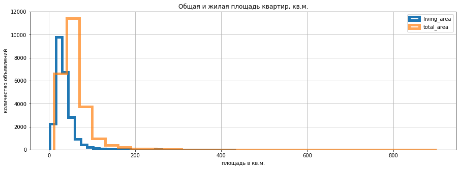

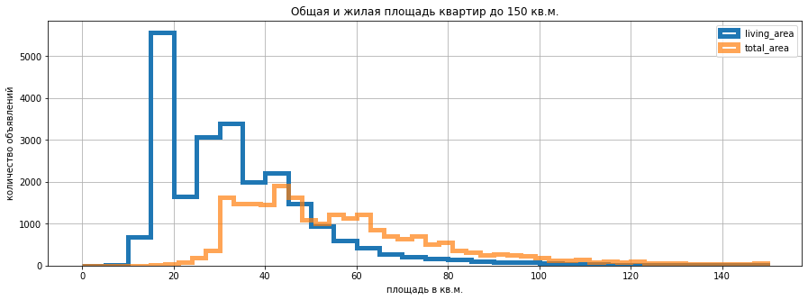

```python
#общая и жилая площадь по всем данным
living_area_hist = df['living_area'].plot(kind='hist', y='total_area',
                histtype='step',bins=30, grid=True, legend=True,alpha=1,
                linewidth=5, figsize=(15, 5)
                )
total_area_hist = df['total_area'].plot(kind='hist', y='total_area',
                histtype='step',bins=30,grid=True, legend=True,alpha=0.7, figsize=(15, 5),
                title='Общая и жилая площадь квартир, кв.м.',linewidth=5, ax=living_area_hist
                 ).set(xlabel='площадь в кв.м.', ylabel='количество объявлений')
plt.show()
#то же детальнее на отрезке до 150 кв.м.
living_area_hist = df['living_area'].plot(kind='hist', y='total_area',
                histtype='step',bins=30,grid=True, legend=True,alpha=1, figsize=(15, 5),
                linewidth=5, range= (0, 150)
                )
total_area_hist = df['total_area'].plot(kind='hist', y='total_area',
                histtype='step',bins=50,grid=True, legend=True,alpha=0.7, figsize=(15, 5),
                title='Общая и жилая площадь квартир до 150 кв.м.',linewidth=5,
                ax=living_area_hist, range= (0, 150)).set(xlabel='площадь в кв.м.',
                ylabel='количество объявлений')
# т.к. квартиры площадью больше 100 кв м - редкость, и относятся к другому сегменту рынка (хай или люкс), то по ним строить
#отдельный график нецелесообразно
```

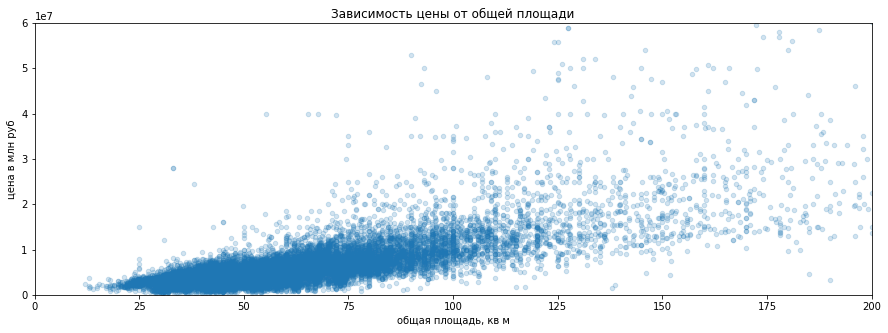

```python
#диаграмма рассеяния (общая площадь и цена )
df.plot(x='total_area', y='last_price', kind='scatter', alpha=0.2, figsize=(15, 5),
                       title='Зависимость цены от общей площади').set(
                       xlabel='общая площадь, кв м', ylabel='цена в млн руб');
plt.xlim(0, 200)
plt.ylim(0, 60000000)
plt.show()
```

```python
#V5
print(f"Линейная корреляция общей площади квартиры и цены {df['total_area'].corr(SPB['last_price']):.3f}")
```

```
Линейная корреляция общей площади квартиры и цены 0.657
```

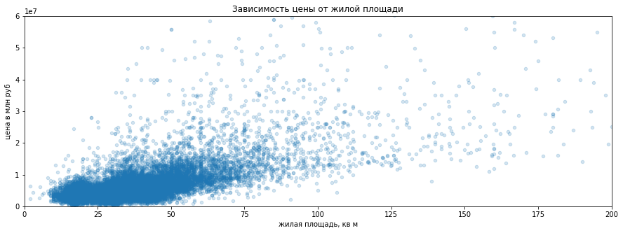

```python
#V5
#диаграмма рассеяния (жилая площадь и цена )
df.plot(x='living_area', y='last_price', kind='scatter', alpha=0.2, figsize=(15, 5),
                       title='Зависимость цены от жилой площади').set(
                       xlabel='жилая площадь, кв м', ylabel='цена в млн руб');
plt.xlim(0, 200)
plt.ylim(0, 60000000)
plt.show()
```

```python
#V5
print(f"Линейная корреляция жилой площади квартиры и цены {df['living_area'].corr(SPB['last_price']):.3f}")
```

```
Линейная корреляция жилой площади квартиры и цены 0.590
```

Наибольшее количество квартир приходится на области до 30 и 50 квм, после 200 они переходят в околонулевое значение, и квартиры из такого сегмента должны рассматриваться отдельно.

Наибольшее количество жилой площади выпадает на пик 20квм - это студии и "однушки" - наиболее массовый сегмент рынка, затем идёт пик в районе 35 - это большие "однушки" и т.н. "евродвушки", то же самое бюджетное жильё, но с претензиями. Пик в районе 40-45 квадратов - это полночценные двухкомнатные квартиры, завершающие самые популярные позиции на рынке.

Пики общей площади укладываются в это же распределение по популярности: студии, "однушки", "двушки".

**V3

**V5

Согласно коэффициенту, существует средняя положительная корреляция между общей площадью квартиры и её ценой, а также жилой площадью и ценой, т.е. можно предполагать, что при увеличении той или иной площади цена квартиры будет стабильно возрастать.

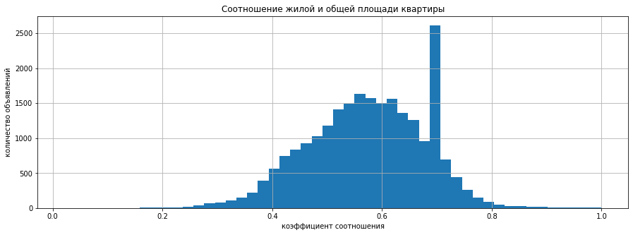

```python
# гистограмма соотношения жилой площади к общей
df['living_area_ratio'].hist(bins=50, figsize=(15, 5)).set(title='Соотношение жилой и общей площади квартиры',
    xlabel='коэффициент соотношения', ylabel='количество объявлений');
```

По гистограмме видно, что массовое распределение идёт в районе 0,6 - 0,7, что характерно для квартир массмаркета, где на нежилые (сервисные) площади уходит почти половина из общей площади квартиры. С увеличением общей площади нежилые помещения занимают примерно прежнее значение (кухни 30 квм и туалеты 15квм тоже бывают, но это из разряда излишеств), и потому их удельный вес на графике падает.

### Зависимость от площади кухни

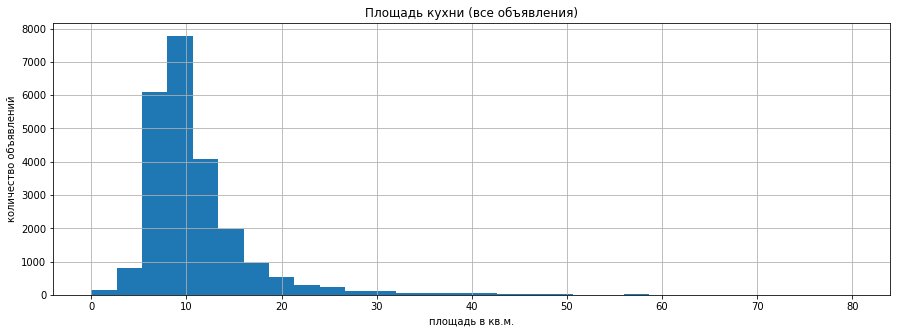

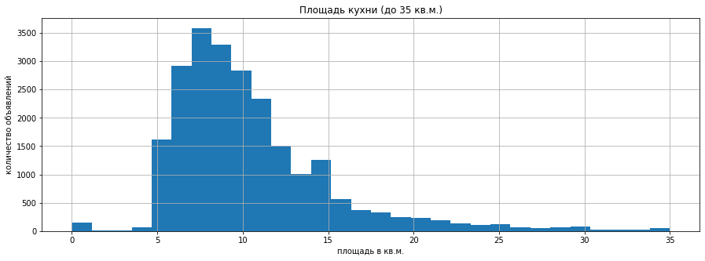

```python
# гистограмма по площади кухни
df['kitchen_area'].hist(bins=30, figsize=(15, 5), range = (0, 80)).set(title='Площадь кухни (все объявления)',
    xlabel='площадь в кв.м.', ylabel='количество объявлений');
plt.show()

#гистограмма выборки (площадь кухни до 35 кв.м.)
df['kitchen_area'].hist(bins=30,  range=(0, 35), figsize=(15, 5) ).set(title='Площадь кухни (до 35 кв.м.)',
                 xlabel='площадь в кв.м.', ylabel='количество объявлений');
```

Второй пик в районе 12-14 квм соответствует 2-к кв, закрывающим самые популярные предложения.

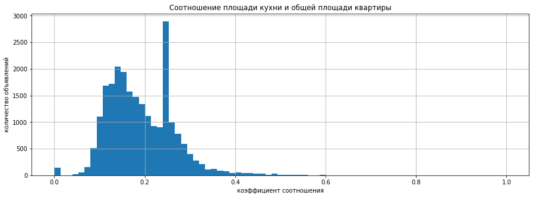

```python
# гистограмма соотношения площади кухни к общей
df['kitchen_area_ratio'].hist(bins=75, figsize=(15, 5), range = (0, 1)).set(title='Соотношение площади кухни и общей площади квартиры',
    xlabel='коэффициент соотношения', ylabel='количество объявлений');
```

- диаграмма для жилплощади в пункте - 8.1 Зависимость от общей площади и жилой площади

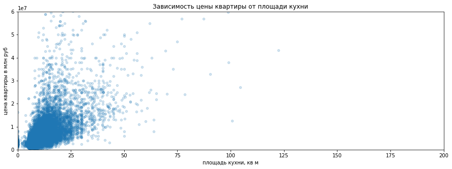

```python
#V4
#диаграмма рассеяния (площадь кухни и цена квартиры)
df.plot(x='kitchen_area', y='last_price', kind='scatter', alpha=0.2, figsize=(15, 5),
                       title='Зависимость цены квартиры от площади кухни').set(
                       xlabel='площадь кухни, кв м', ylabel='цена квартиры в млн руб');
plt.xlim(0, 200)
plt.ylim(0, 60000000)
plt.show()
```

В целом, до границы в 25 кв м наблюдается достаточно линейная зависимость - увеличение кухни как производная от увеличения общей площади и цены квартиры. В дальнейшем, когда в дело вступают иные факторы (например, класс жилья), зависимость теряет значение.

```python
#V5
print(f"Линейная корреляция площади кухни и цены картиры {df['kitchen_area'].corr(SPB['last_price']):.3f}")
```

```
Линейная корреляция площади кухни и цены картиры 0.522
```

**V5

Согласно коэффициенту, существует средняя положительная корреляция между площадью кухни и ценой квартиры, т.е. можно предполагать, что при увеличении площади кухни цена будет стабильно возрастать.

**V5 коэф корелляции и график цены ЖП добавлен в пункт 8.1 Зависимость от общей площади и жилой площади